# nba_en

NBA Player Salary Prediction

Python Application Using AdaBoost Algorithm

[Chinese Version](https://xsong.ltd/archives/pandas/nba)

Author：[Xiao Song](https://xsong.ltd/en) a.k.a. Malcolm

# Table of Contents

[figure not shown]

# Data Cleaning

- [Data from Kaggle](https://www.kaggle.com/koki25ando/nba-salary-prediction-using-multiple-regression/comments)

```python
import os
import pandas as pd
import numpy as np
import matplotlib.pyplot as plt
import seaborn as sns
sns.set_style("whitegrid") #use this plot theme
salary_table =pd.read_csv("E:\\R_codes\\others\\nba\\NBA_season1718_salary.csv",header=0,index_col=None,encoding = 'utf-8')
salary_table=salary_table[['Player','season17_18']]
salary_table=salary_table.rename(columns={'season17_18':'salary17_18'}) #variable rename
salary_table['salary17_18']=salary_table['salary17_18']/1000000 #transform salary to 'million'
```

# Descriptive Statistics

## Independent Variables

- Variable Explaining

| Variable | meaning |
| --- | --- |
| Pos | Position |
| MPG | Average Minutes played Per Game |
| PPG | Average Points Per Game |
| APG | Average Assists Per Game |
| RPG | Average Rebounds Per Game |
| TOPG | Average Turnovers Per Game |
| BPG | Average Blocks Per Game |
| SPG | Average Steals Per Game |
| PER | Player Efficiency Rating |
| G | Games Attended |
| AGE | Age |
| salary17_18 | 2017-2018 Salary(million) |

```python
ss =pd.read_csv("E:\\R_codes\\others\\nba\\Seasons_Stats.csv",header=0,index_col=None,encoding = 'utf-8')
ss = ss[ss['Year']>=2017] # keep 2017-2018 data
stats17 = ss[['Year','Player','Pos','Age','G','PER','MP','PTS','AST','TRB','TOV','BLK','STL']]
stats17.drop_duplicates(subset=['Player'],keep='first',inplace=True) #drop duplicate data
stats17['MPG'] =stats17['MP']/stats17['G']
stats17['PPG'] =stats17['PTS']/stats17['G']
stats17['APG'] =stats17['AST']/stats17['G']
stats17['RPG'] =stats17['TRB']/stats17['G']
stats17['TOPG'] =stats17['TOV']/stats17['G']
stats17['BPG'] =stats17['BLK']/stats17['G']
stats17['SPG'] =stats17['STL']/stats17['G']
stats17['Pos'][stats17['Pos']=='PF-C'] = 'PF' #recode data
#data merge
stats_salary = pd.merge(stats17, salary_table)
```

[output not shown]

- Average Points Per Game Ranking

```python
stats_salary.drop_duplicates(subset=['Player'],keep='first',inplace=True)
stats_salary=stats_salary.sort_values(by='PPG',ascending=False)
PPG = stats_salary[['Player','PPG']]
PPG.head(10)
```

|  | Player | PPG |
| --- | --- | --- |
| 418 | Russell Westbrook | 31.580247 |
| 164 | James Harden | 29.086420 |
| 384 | Isaiah Thomas | 28.934211 |
| 97 | Anthony Davis | 27.986667 |
| 105 | DeMar DeRozan | 27.297297 |
| 248 | Damian Lillard | 26.986667 |
| 86 | DeMarcus Cousins | 26.972222 |
| 204 | LeBron James | 26.405405 |
| 241 | Kawhi Leonard | 25.513514 |
| 95 | Stephen Curry | 25.303797 |

- Player Efficiency Rating Ranking

```python
stats_salary=stats_salary.sort_values(by='PER',ascending=False)
PER = stats_salary[['Player','PER']]
PER.head(10)
```

|  | Player | PER |
| --- | --- | --- |
| 200 | Demetrius Jackson | 30.8 |
| 418 | Russell Westbrook | 30.6 |
| 261 | Boban Marjanovic | 29.6 |
| 114 | Kevin Durant | 27.6 |
| 97 | Anthony Davis | 27.5 |
| 241 | Kawhi Leonard | 27.5 |
| 164 | James Harden | 27.3 |
| 204 | LeBron James | 27.0 |
| 384 | Isaiah Thomas | 26.5 |
| 218 | Nikola Jokic | 26.4 |

- High Age Players Ranking

```python
stats_salary=stats_salary.sort_values(by='Age',ascending=False)
Age = stats_salary[['Player','Age']]
Age.head(10)
```

|  | Player | Age |
| --- | --- | --- |
| 70 | Vince Carter | 40.0 |
| 383 | Jason Terry | 39.0 |
| 325 | Paul Pierce | 39.0 |
| 147 | Manu Ginobili | 39.0 |
| 303 | Dirk Nowitzki | 38.0 |
| 172 | Udonis Haslem | 36.0 |
| 112 | Mike Dunleavy | 36.0 |
| 89 | Jamal Crawford | 36.0 |
| 206 | Richard Jefferson | 36.0 |
| 26 | Matt Barnes | 36.0 |

[figure not shown]

- In the turnover list per game, James Harden ranked first, this should be related to the ball, and will be verified later.

```python
stats_salary=stats_salary.sort_values(by='TOPG',ascending=False)
RPG = stats_salary[['Player','TOPG']]
RPG.head(10)
```

|  | Player | TOPG |
| --- | --- | --- |
| 164 | James Harden | 5.728395 |
| 418 | Russell Westbrook | 5.407407 |
| 410 | John Wall | 4.141026 |
| 204 | LeBron James | 4.094595 |
| 121 | Joel Embiid | 3.774194 |
| 86 | DeMarcus Cousins | 3.736111 |
| 44 | Eric Bledsoe | 3.378788 |
| 359 | Dennis Schroder | 3.265823 |
| 49 | Devin Booker | 3.089744 |
| 95 | Stephen Curry | 3.025316 |

### Data Visualization

- Correlation Plot

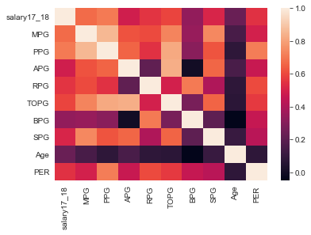

```python
heat_salary=stats_salary.drop(['Year', 'Player'], axis='columns')
heat_salary=stats_salary[['salary17_18','Pos','MPG','PPG','APG','RPG','TOPG','BPG','SPG','Age','PER']]
dfData = heat_salary.corr()
sns.heatmap(dfData)
```

- Age and multiple data indicators are weakly correlated.
- Average turnovers per game and playing time have strong correlation, and it might explain why James Harden has some many turnovers averagely.
- Because of position, there is almost no correlation between averaging blocks and assists per game.
- Correlation between Points per game and age

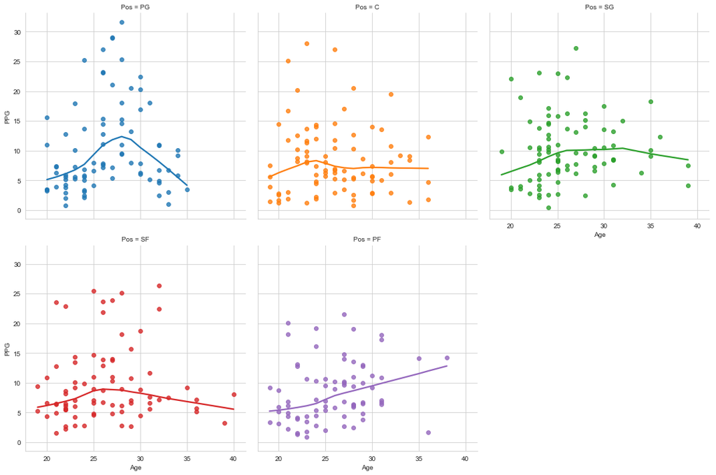

```python
sns.lmplot(x="Age", y="PPG",hue="Pos",col="Pos",col_wrap=3, data=stats_salary,lowess=True)
```

For point guards, age and average scores are inverse U-shaped.

Which position is the most prone to turnovers?

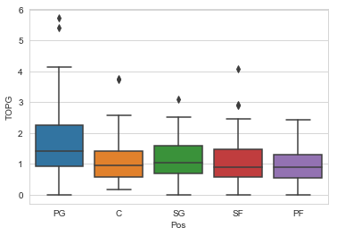

```python
sns.boxplot(x="Pos", y="TOPG", data=stats_salary)
```

Answer：Point Guards

Who has the most blocks? no doubt

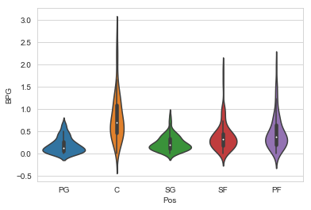

```python
sns.violinplot(x="Pos", y="BPG", data=stats_salary)
```

## Dependent Variable

```python
salary_table['salary17_18'].describe()
```

```
count    573.000000
mean       5.858946
std        7.162373
min        0.017224
25%        1.312611
50%        2.386864
75%        7.936509
max       34.682550
Name: salary17_18, dtype: float64
```

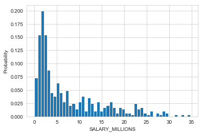

```python
plt.hist(stats_salary['salary17_18'],density=True,bins=50)
plt.xlabel('SALARY_MILLIONS')
plt.ylabel('Probability')
plt.show()
```

# Algorithms

## CART (Regression)

```python
from sklearn import tree
from sklearn.externals.six import StringIO
import pydotplus
import graphviz
from IPython.display import Image
import os
from sklearn.model_selection import train_test_split

stats_salary = stats_salary.dropna()
Y = heat_salary['salary17_18']
X = heat_salary.drop(['salary17_18','Pos'],axis=1)
x_train, x_test, y_train, y_test = train_test_split(X, Y, test_size = 0.3) #split data

clf = tree.DecisionTreeRegressor(max_depth=4,criterion="mse") #regression tree
clf = clf.fit(x_train, y_train)
x_test['Pred_Y']=clf.predict(x_test)
#y_test.join(cc,how='right')
fft = pd.merge(stats_salary,x_test,how='right')
x_test = x_test.drop(['Pred_Y'],axis=1)
fft=fft[['Player','salary17_18','Pred_Y']]
fft=fft.sort_values(by='salary17_18',ascending=False)
```

- Comparison of real and predicted values (Test data)

```python
fft.head(20)
```

|  | Player | salary17_18 | Pred_Y |
| --- | --- | --- | --- |
| 0 | LeBron James | 33.285709 | 22.158333 |
| 6 | Blake Griffin | 29.512900 | 22.158333 |
| 4 | Kyle Lowry | 28.703704 | 22.158333 |
| 8 | Mike Conley | 28.530608 | 22.158333 |
| 3 | Bradley Beal | 23.775506 | 22.158333 |
| 25 | DeAndre Jordan | 22.642350 | 13.311576 |
| 29 | Steven Adams | 22.471910 | 6.337344 |
| 14 | Nicolas Batum | 22.434783 | 15.510193 |
| 10 | George Hill | 20.000000 | 22.158333 |
| 21 | Ryan Anderson | 19.578455 | 7.368963 |
| 13 | Jeff Teague | 19.000000 | 22.158333 |
| 2 | John Wall | 18.063850 | 22.158333 |
| 5 | Klay Thompson | 17.826150 | 22.158333 |
| 20 | Kentavious Caldwell-Pope | 17.745894 | 7.368963 |
| 79 | Bismack Biyombo | 17.000000 | 13.311576 |
| 23 | Robert Covington | 16.698103 | 13.311576 |
| 87 | Ian Mahinmi | 16.661641 | 5.408215 |
| 55 | Tristan Thompson | 16.400000 | 13.311576 |
| 28 | Jonas Valanciunas | 15.460675 | 13.311576 |
| 50 | DeMarre Carroll | 14.800000 | 7.026022 |

- Compute MSE

```python
from sklearn.metrics import mean_squared_error
mean_squared_error(fft['salary17_18'],fft['Pred_Y'])
```

```
22.347297473752615
```

- Tree Plot

```python
os.environ["PATH"] += os.pathsep + 'C:/graphviz-2.38/release/bin/'
dot_data = tree.export_graphviz(clf,filled=True,rounded=True,feature_names=X.columns,class_names=Y,special_characters=True)
graphviz.Source(dot_data)
```

[figure not shown]

- Feature Selection Using Important

```python
from tabulate import tabulate
headers = ["name", "score"]
values = sorted(zip(x_train.columns, clf.feature_importances_), key=lambda x: x[1] * -1)
print(tabulate(values, headers, tablefmt="plain"))
```

```
name         score
PPG     0.575584
Age     0.13161
MPG     0.0935031
RPG     0.0774545
PER     0.0755043
BPG     0.0453367
APG     0.00100781
TOPG    0
SPG     0
```

- Unsurprisingly, the average score has the greatest impact on salary levels. The second factor is age. Average turnover and steals have no effect on salary.

## Ensemble Learning：AdaBoost Regressor

```python
from sklearn.tree import DecisionTreeRegressor
from sklearn.ensemble import AdaBoostRegressor
stats_salary = stats_salary.dropna()
regr = AdaBoostRegressor(DecisionTreeRegressor(max_depth=5),
                          n_estimators=500)
regr.fit(x_train, y_train)
x_test['Pred_Y']=regr.predict(x_test)
```

- display some of test data prediction results

```python
fft = pd.merge(stats_salary,x_test,how='right')
x_test = x_test.drop(['Pred_Y'],axis=1)
fft=fft[['Player','salary17_18','Pred_Y']]
fft=fft.sort_values(by='salary17_18',ascending=False)
fft.head(20)
```

|  | Player | salary17_18 | Pred_Y |
| --- | --- | --- | --- |
| 0 | LeBron James | 33.285709 | 26.199097 |
| 6 | Blake Griffin | 29.512900 | 24.958024 |
| 4 | Kyle Lowry | 28.703704 | 26.902525 |
| 8 | Mike Conley | 28.530608 | 17.866278 |
| 3 | Bradley Beal | 23.775506 | 17.426276 |
| 25 | DeAndre Jordan | 22.642350 | 20.414776 |
| 29 | Steven Adams | 22.471910 | 11.704120 |
| 14 | Nicolas Batum | 22.434783 | 15.739906 |
| 10 | George Hill | 20.000000 | 14.857400 |
| 21 | Ryan Anderson | 19.578455 | 10.551098 |
| 13 | Jeff Teague | 19.000000 | 20.296645 |
| 2 | John Wall | 18.063850 | 25.230272 |
| 5 | Klay Thompson | 17.826150 | 19.021876 |
| 20 | Kentavious Caldwell-Pope | 17.745894 | 12.417650 |
| 79 | Bismack Biyombo | 17.000000 | 12.356802 |
| 23 | Robert Covington | 16.698103 | 12.417650 |
| 87 | Ian Mahinmi | 16.661641 | 7.143326 |
| 55 | Tristan Thompson | 16.400000 | 12.855073 |
| 28 | Jonas Valanciunas | 15.460675 | 14.669076 |
| 50 | DeMarre Carroll | 14.800000 | 11.490473 |

- Compute AdaBoost's MSE

```python
from sklearn.metrics import mean_squared_error
mean_squared_error(fft['salary17_18'],fft['Pred_Y'])
```

```
14.893289125247367
```

Apperantly，AdaBoost has a higher prediction accuracy.

- Variable Importance

```python
headers = ["name", "score"]
values = sorted(zip(x_train.columns, regr.feature_importances_), key=lambda x: x[1] * -1)
print(tabulate(values, headers, tablefmt="plain"))
```

```
name        score
MPG     0.215558
PER     0.144803
PPG     0.138573
Age     0.113343
RPG     0.111188
APG     0.0891605
TOPG    0.0643181
SPG     0.0635352
BPG     0.0595221
```

- The results of the AdaBoost algorithm show that the average playing time and efficiency rate have the most important impact on salary, while the average score is only ranked third. This is quite different from the decision tree results.